# Combine Datasets

```python
import os
import pandas as pd

base_dir = os.getcwd()
data_dir = os.path.join(base_dir, 'Ausgrid_solar_home_data')

# Load processed datasets
ausgrid = pd.read_csv(os.path.join(data_dir, "ausgrid_processed.csv"))
weather = pd.read_csv(os.path.join(data_dir, "weather_data_processed.csv"))

# Combine datasets
df = ausgrid.merge(weather, on="datetime", how="left")
df.head()
```

|  | Customer | Generator Capacity | Postcode | Consumption Category | datetime | kWh | Unnamed: 0 | temperature_2m | shortwave_radiation | precipitation |
| --- | --- | --- | --- | --- | --- | --- | --- | --- | --- | --- |
| 0 | 1 | 3.78 | 2076 | CL | 2010-07-01 00:00:00 | 1.075 | 0.0 | 3.60 | 0.0 | 0.0 |
| 1 | 1 | 3.78 | 2076 | CL | 2010-07-01 00:30:00 | 1.250 | 1.0 | 3.45 | 0.0 | 0.0 |
| 2 | 1 | 3.78 | 2076 | CL | 2010-07-01 01:00:00 | 1.244 | 2.0 | 3.30 | 0.0 | 0.0 |
| 3 | 1 | 3.78 | 2076 | CL | 2010-07-01 01:30:00 | 1.256 | 3.0 | 2.75 | 0.0 | 0.0 |
| 4 | 1 | 3.78 | 2076 | CL | 2010-07-01 02:00:00 | 0.744 | 4.0 | 2.20 | 0.0 | 0.0 |

The Ausgrid dataset uses three consumption categories:

- GC: General Consumption
- CL: Controlled Load
- GG: Gross Generation (solar PV generation)

Consider a real distribution system. Net load is monitored for each customer, but residential solar generation may not be directly measured. The size, orientation, and other characteristics of the solar installations may also be unknown. Our goal is to disaggregate net load into base load and PV generation. Net load is given by $P_\text{net} = P_\text{load} - P_\text{PV}$ where $P_\text{load} = GC + CL$. We can do this by predicting $P_\text{PV}$.

A common simplified equation for PV power output is:

$P_\text{PV} = P_\text{rated} \frac{G}{G_\text{STC}}[1 + \gamma (T_\text{cell} - T_\text{STC})]$

- $P_\text{PV}$ = PV electrical power output (kW).
- $P_\text{rated}$ = rated/nominal PV system capacity (kW).
- G = indicent solar irradiance on the panels (W/m^2).
- $G_\text{STC}$ = reference irradiance at standard test conditions, typically 1000 W/m^2.
- $T_\text{cell}$ = PV cell temperature (C)
- $T_\text{STC}$ = reference cell temperature, typically 25 C.
- $\gamma$ = temperature coefficient of power (per C), normally negative.

Irradiance primarily determines how much power is available, where cell temperature modifies the output. Solar irradiance is the solar power received per unit area, typically measured in W/m^2. For PV modeling, it ideally refers to the radiation incident on the panel surface. Shortwave radiation is a broader atmospheric measurement of incoming radiation in the shortwave portion of the spectrum, also measured in W/m^2. In our dataset, `shortwave_radiation` can serve as a proxy for the solar irradiance available to the PV system.

The rated PV system capacity $P_\text{rated}$ is unknown. The incident solar radiation $G$ can be estimated from `shortwave_radiation` and the position of the sun, which can in turn be estimated from the `hour of day` and the `geographical location` of the system. A useful starting point to to model the irradiance incident on the PV panels as:

$G(t) = S(t) f(\theta_\text{sun}(t, \phi, \lambda), \beta)$

- $G(t)$ = irradiance incident on the PV panels at time t (W/m^2)
- $S(t)$ = measured shortwave radiation (W/m^2)
- t = time of day/date.
- $\phi, \lambda$ = latitude and longitude of the PV system.
- $\theta_\text{sun}$ = solar position.
- $\beta$ = panel tilt, which is unknown and must be estimated.
- $f(\dot)$ = function describing how solar position and panel orientation determine the radiation incident on the panel.

$\theta_\text{sun} = \sin \phi \sin \delta + \cos \phi \cos \delta \cos H$

- $\delta$ = solar declination, determined by the date.
- $H$ = solar hour angle, determined by time of day.

$\delta = 23.45 \degree \sin (\frac{360 \degree}{365}(284 + n))$

- $n$ = day of year (1-365)

$f(\theta_\text{sun}, \beta) = \max (0, \cos(\theta_\text{sun} - \beta))$

The expression for $P_\text{PV}$ becomes:

$P_\text{PV} = P_\text{rated} \times \frac{ S(t) \max(0, \cos(\theta_\text{sun} - \beta))}{G_\text{STC}} [1 + \gamma(T_\text{cell} - T_\text{STC})]$

Replace $P_\text{rated}$ with parameter $\alpha$ which represents unknown characteristics of the PV system affecting maximum output, such as area and number of panels. The parameter $\beta$ represents the unknown angle of the panels. The parameter $\gamma$ represents the unknown temperature coefficient of power.

## Calculate Sun Position

```python
import numpy as np
import pandas as pd

lat = 33.9 # system latitude (degrees)
lon = 151.2 # system longitude (degrees)

# Convert string to datetime type
df["datetime"] = pd.to_datetime(df["datetime"])

sun = pd.DataFrame({"datetime": df["datetime"]})
sun["day_of_year"] = sun["datetime"].dt.dayofyear
sun["hour"] = sun["datetime"].dt.hour + sun["datetime"].dt.minute / 60

# Solar declination
sun["declination_angle"] = np.radians(23.45 * np.sin(np.radians((360 / 365) * (284 + sun["day_of_year"]))))

# Solar hour angle (simplified: 15° per hour from solar noon)
hour_angle = np.radians(15 * (sun['hour'] - 12))

# Solar zenith angle
lat_rad = np.radians(lat)
sun["sun_position"] = np.degrees(np.arccos(
    np.sin(lat_rad) * np.sin(sun["declination_angle"]) +
    np.cos(lat_rad) * np.cos(sun["declination_angle"]) * np.cos(hour_angle)))

# Make sure sun does not have duplicate datetime values
sun = sun[["datetime", "sun_position"]].drop_duplicates("datetime")

sun.head()
```

|  | datetime | sun_position |
| --- | --- | --- |
| 0 | 2010-07-01 00:00:00 | 122.979516 |
| 1 | 2010-07-01 00:30:00 | 122.534587 |
| 2 | 2010-07-01 01:00:00 | 121.220214 |
| 3 | 2010-07-01 01:30:00 | 119.093277 |
| 4 | 2010-07-01 02:00:00 | 116.236036 |

### Append sun position to original dataset

```python
df = df.merge(
    sun[["datetime", "sun_position"]],
    on="datetime",
    how="left")

df.head()
```

|  | Customer | Generator Capacity | Postcode | Consumption Category | datetime | kWh | Unnamed: 0 | temperature_2m | shortwave_radiation | precipitation | sun_position |
| --- | --- | --- | --- | --- | --- | --- | --- | --- | --- | --- | --- |
| 0 | 1 | 3.78 | 2076 | CL | 2010-07-01 00:00:00 | 1.075 | 0.0 | 3.60 | 0.0 | 0.0 | 122.979516 |
| 1 | 1 | 3.78 | 2076 | CL | 2010-07-01 00:30:00 | 1.250 | 1.0 | 3.45 | 0.0 | 0.0 | 122.534587 |
| 2 | 1 | 3.78 | 2076 | CL | 2010-07-01 01:00:00 | 1.244 | 2.0 | 3.30 | 0.0 | 0.0 | 121.220214 |
| 3 | 1 | 3.78 | 2076 | CL | 2010-07-01 01:30:00 | 1.256 | 3.0 | 2.75 | 0.0 | 0.0 | 119.093277 |
| 4 | 1 | 3.78 | 2076 | CL | 2010-07-01 02:00:00 | 0.744 | 4.0 | 2.20 | 0.0 | 0.0 | 116.236036 |

Our model is simplified to: $P_\text{PV}(t) = C \times S(t) \times \theta_\text{sun}(t) \frac{1 + \gamma (T_\text{Cell}(t) - T_\text{STC})}{G_\text{STC}}$

- $S(t)$ is `shortwave_radiation`.
- $\theta_\text{sun}(t)$ is the position of the sun
- $T_\text{cell}(t)$ is estimated as `temperature_2m`.
- $T_\text{STC}$ and $G_\text{STC}$ are known constants.
- $C$ is a per-customer unknown parameter accounting for PV system characteristics such as total generating capacity and panel tilt angle.
- $\gamma$ is a per-customer unknown parameter representing the PV system's temperature coefficient of power (per C).

# Parameter Estimation

## Modify the dataset

```python
df["Pload"] = df["kWh"].where(df["Consumption Category"].isin(["GC", "CL"]), 0)
df["PPV"]   = df["kWh"].where(df["Consumption Category"] == "GG", 0)
df["Pnet"]  = df["Pload"] - df["PPV"]
df.drop(columns=["Consumption Category", "kWh"], inplace=True)
df.head()
```

|  | Customer | Generator Capacity | Postcode | datetime | Unnamed: 0 | temperature_2m | shortwave_radiation | precipitation | sun_position | Pload | PPV | Pnet |
| --- | --- | --- | --- | --- | --- | --- | --- | --- | --- | --- | --- | --- |
| 0 | 1 | 3.78 | 2076 | 2010-07-01 00:00:00 | 0.0 | 3.60 | 0.0 | 0.0 | 122.979516 | 1.075 | 0.0 | 1.075 |
| 1 | 1 | 3.78 | 2076 | 2010-07-01 00:30:00 | 1.0 | 3.45 | 0.0 | 0.0 | 122.534587 | 1.250 | 0.0 | 1.250 |
| 2 | 1 | 3.78 | 2076 | 2010-07-01 01:00:00 | 2.0 | 3.30 | 0.0 | 0.0 | 121.220214 | 1.244 | 0.0 | 1.244 |
| 3 | 1 | 3.78 | 2076 | 2010-07-01 01:30:00 | 3.0 | 2.75 | 0.0 | 0.0 | 119.093277 | 1.256 | 0.0 | 1.256 |
| 4 | 1 | 3.78 | 2076 | 2010-07-01 02:00:00 | 4.0 | 2.20 | 0.0 | 0.0 | 116.236036 | 0.744 | 0.0 | 0.744 |

## Remove Missing Data

```python
# Remove the unnamed column
df = df.drop(columns=["Unnamed: 0"])

# Remove rows containing any missing values
df = df.dropna()

# Count NaNs in each column
display(df.isna().sum())
```

```
Customer               0
Generator Capacity     0
Postcode               0
datetime               0
temperature_2m         0
shortwave_radiation    0
precipitation          0
sun_position           0
Pload                  0
PPV                    0
Pnet                   0
dtype: int64
```

## Split Training and Testing Data

```python
# Randomly split each customer's data 80/20
train_df = (
    df.groupby("Customer", group_keys=False)
      .sample(frac=0.8, random_state=42))

# Everything not selected for training goes into testing
test_df = df.drop(train_df.index)

# Optional: reset indices
train_df = train_df.reset_index(drop=True)
test_df = test_df.reset_index(drop=True)
```

## Perform Parameter Estimation

```python
import numpy as np
from scipy.optimize import least_squares

G_STC = 1000
T_STC = 25

def residuals(params, S, theta_sun, T, P):
    alpha, beta, gamma = params

    # Irradiance adjustment for panel tilt
    incidence_factor = np.maximum(0, np.cos(np.radians(theta_sun - beta)))

    # Predicted PV energy (kWh per 30-minute interval)
    P_hat = (
        alpha
        * S / G_STC
        * incidence_factor
        * (1 + gamma * (T - T_STC))
        * 0.5)

    return P_hat - P

results = []

for customer, group in train_df.groupby("Customer"):
    S = group["shortwave_radiation"].values
    theta_sun = group["sun_position"].values
    T = group["temperature_2m"].values
    P = group["PPV"].values

    # Initial guesses: capacity, panel tilt, temperature coefficient
    initial_guess = [
        group["Generator Capacity"].iloc[0],
        30,
        -0.004]

    # Estimate alpha, beta, and gamma
    fit = least_squares(
        residuals,
        x0=initial_guess,
        bounds=(
            [0, 0, -0.02],
            [np.inf, 90, 0.02]),
        args=(S, theta_sun, T, P))

    results.append([
        customer,
        fit.x[0],
        fit.x[1],
        fit.x[2]])

parameters = pd.DataFrame(
    results,
    columns=["Customer", "alpha", "beta", "gamma"])

parameters.head()
```

|  | Customer | alpha | beta | gamma |
| --- | --- | --- | --- | --- |
| 0 | 1 | 1.119017 | 35.992530 | 0.006523 |
| 1 | 2 | 0.481045 | 25.803825 | -0.017665 |
| 2 | 3 | 0.338140 | 31.152128 | -0.001233 |
| 3 | 4 | 0.270474 | 35.361862 | -0.007458 |
| 4 | 5 | 0.265757 | 32.845339 | -0.007325 |

## Train Results

```python
display(parameters.columns)
```

```
Index(['Customer', 'alpha', 'beta', 'gamma'], dtype='str')
```

```python
# Remove existing parameter columns
train_df = train_df.drop(
    columns=["alpha", "beta", "gamma"],
    errors="ignore")

# Add updated parameters
train_df = train_df.merge(
    parameters[["Customer", "alpha", "beta", "gamma"]],
    on="Customer",
    how="left")

# Remove duplicate customer-datetime observations
train_df = train_df.drop_duplicates(subset=["Customer", "datetime"])

# Sort chronologically within each customer
train_df = train_df.sort_values(["Customer", "datetime"]).reset_index(drop=True)

train_df.head()
```

|  | Customer | Generator Capacity | Postcode | datetime | temperature_2m | shortwave_radiation | precipitation | sun_position | Pload | PPV | Pnet | alpha | beta | gamma |
| --- | --- | --- | --- | --- | --- | --- | --- | --- | --- | --- | --- | --- | --- | --- |
| 0 | 1 | 3.78 | 2076 | 2010-07-01 00:00:00 | 3.60 | 0.0 | 0.0 | 122.979516 | 1.075 | 0.0 | 1.075 | 1.119017 | 35.99253 | 0.006523 |
| 1 | 1 | 3.78 | 2076 | 2010-07-01 00:30:00 | 3.45 | 0.0 | 0.0 | 122.534587 | 0.000 | 0.0 | 0.000 | 1.119017 | 35.99253 | 0.006523 |
| 2 | 1 | 3.78 | 2076 | 2010-07-01 01:00:00 | 3.30 | 0.0 | 0.0 | 121.220214 | 0.471 | 0.0 | 0.471 | 1.119017 | 35.99253 | 0.006523 |
| 3 | 1 | 3.78 | 2076 | 2010-07-01 01:30:00 | 2.75 | 0.0 | 0.0 | 119.093277 | 0.083 | 0.0 | 0.083 | 1.119017 | 35.99253 | 0.006523 |
| 4 | 1 | 3.78 | 2076 | 2010-07-01 02:00:00 | 2.20 | 0.0 | 0.0 | 116.236036 | 0.744 | 0.0 | 0.744 | 1.119017 | 35.99253 | 0.006523 |

```python
# Panel incidence factor
incidence_factor = np.maximum(0,np.cos(np.radians(train_df["sun_position"] - train_df["beta"])))

# Predict PV generation
train_df["PPV_pred"] = (
    train_df["alpha"]
    * train_df["shortwave_radiation"] / 1000
    * incidence_factor
    * (1 + train_df["gamma"] * (train_df["temperature_2m"] - 25))
    * 0.5)

# Compare predicted vs. true PV generation
comparison = train_df[["Customer", "PPV", "PPV_pred"]]
comparison.head()
```

|  | Customer | PPV | PPV_pred |
| --- | --- | --- | --- |
| 0 | 1 | 0.0 | 0.0 |
| 1 | 1 | 0.0 | 0.0 |
| 2 | 1 | 0.0 | 0.0 |
| 3 | 1 | 0.0 | 0.0 |
| 4 | 1 | 0.0 | 0.0 |

```python
# Plot
import matplotlib.pyplot as plt
plt.rcParams["agg.path.chunksize"] = 10000

customer = train_df["Customer"].iloc[0]
plot_df = (
    train_df[train_df["Customer"] == customer]
    .sort_values("datetime"))

plot_df.head()
```

|  | Customer | Generator Capacity | Postcode | datetime | temperature_2m | shortwave_radiation | precipitation | sun_position | Pload | PPV | Pnet | alpha | beta | gamma | PPV_pred |
| --- | --- | --- | --- | --- | --- | --- | --- | --- | --- | --- | --- | --- | --- | --- | --- |
| 0 | 1 | 3.78 | 2076 | 2010-07-01 00:00:00 | 3.60 | 0.0 | 0.0 | 122.979516 | 1.075 | 0.0 | 1.075 | 1.119017 | 35.99253 | 0.006523 | 0.0 |
| 1 | 1 | 3.78 | 2076 | 2010-07-01 00:30:00 | 3.45 | 0.0 | 0.0 | 122.534587 | 0.000 | 0.0 | 0.000 | 1.119017 | 35.99253 | 0.006523 | 0.0 |
| 2 | 1 | 3.78 | 2076 | 2010-07-01 01:00:00 | 3.30 | 0.0 | 0.0 | 121.220214 | 0.471 | 0.0 | 0.471 | 1.119017 | 35.99253 | 0.006523 | 0.0 |
| 3 | 1 | 3.78 | 2076 | 2010-07-01 01:30:00 | 2.75 | 0.0 | 0.0 | 119.093277 | 0.083 | 0.0 | 0.083 | 1.119017 | 35.99253 | 0.006523 | 0.0 |
| 4 | 1 | 3.78 | 2076 | 2010-07-01 02:00:00 | 2.20 | 0.0 | 0.0 | 116.236036 | 0.744 | 0.0 | 0.744 | 1.119017 | 35.99253 | 0.006523 | 0.0 |

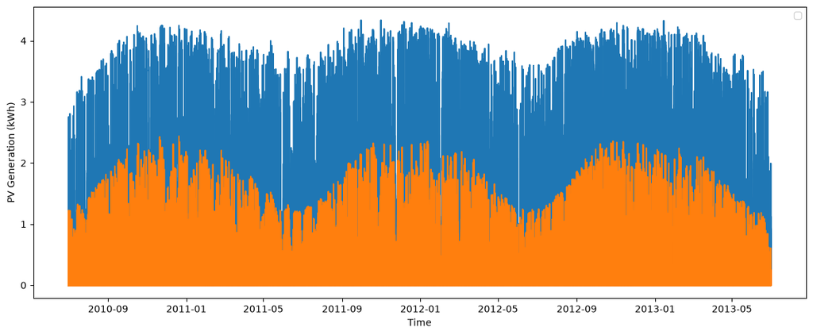

```python
plt.figure(figsize=(12, 5))
plt.plot(train_df["datetime"], train_df["PPV"])
plt.plot(train_df["datetime"], train_df["PPV_pred"])
# plt.plot(train_df["datetime"], train_df["PPV"], label="True PPV")
# plt.plot(train_df["datetime"], train_df["PPV_pred"], label="Predicted PPV")
plt.xlabel("Time")
plt.ylabel("PV Generation (kWh)")
plt.legend(loc="upper right")
plt.tight_layout()
plt.show()
```

The results on the training data are showing systematic offset. Our first tpe is to check the scale of `alpha` versus `Generator Capacity`. If alpha is consistently smaller than actual generating capacity, that would explain the offset.

```python
check = train_df[["Customer", "Generator Capacity"]].drop_duplicates(
    "Customer").merge(parameters, on="Customer")

check["alpha_ratio"] = check["alpha"] / check["Generator Capacity"]
check[["Generator Capacity", "alpha", "alpha_ratio"]].describe()
```

|  | Generator Capacity | alpha | alpha_ratio |
| --- | --- | --- | --- |
| count | 300.000000 | 300.000000 | 300.000000 |
| mean | 1.683300 | 0.602797 | 0.356433 |
| std | 1.036846 | 0.412600 | 0.080065 |
| min | 1.000000 | 0.202756 | 0.174844 |
| 25% | 1.020000 | 0.376698 | 0.292587 |
| 50% | 1.500000 | 0.488990 | 0.339769 |
| 75% | 2.000000 | 0.686975 | 0.422857 |
| max | 9.990000 | 4.509278 | 0.624316 |

The next useful diagnostic is to compare the estimated $\beta$ across customers.

```python
display(parameters["beta"].describe())
parameters[["Customer", "beta"]].sort_values("beta")
print("At 0°:", (parameters["beta"] == 0).sum())
print("At 90°:", (parameters["beta"] == 90).sum())
```

```
count    300.000000
mean      35.282534
std       12.782116
min        7.400015
25%       28.203961
50%       33.278948
75%       39.947769
max       90.000000
Name: beta, dtype: float64
```

```
At 0°: 0
At 90°: 0
```

The estimated $\beta$ values look reasonable. No estimates hit either bound ($0\degree$ or $90\degree$). The mean angle is $35.3 \degree$ and most panels fall within $28.2 \degree - 39.9 \degree$. This is consistent with the model finding a meaningful tilt parameter.

Finally, we check $\gamma$.

```python
display(parameters["gamma"].describe())
parameters[["Customer", "gamma"]].sort_values("gamma")
print("Near -0.02:", (parameters["gamma"] <= -0.01999).sum())
print("Near 0.02:", (parameters["gamma"] >= 0.01999).sum())
```

```
count    300.000000
mean      -0.004127
std        0.009537
min       -0.020000
25%       -0.011088
50%       -0.006121
75%        0.002002
max        0.020000
Name: gamma, dtype: float64
```

```
Near -0.02: 8
Near 0.02: 11
```

19 out of 300 customers (~6.3%) have $\gamma$ essentially at an imposed bound. For these customers, the optimizer may be using the temperature coefficient to compensate for limitations elsewhere in the model.

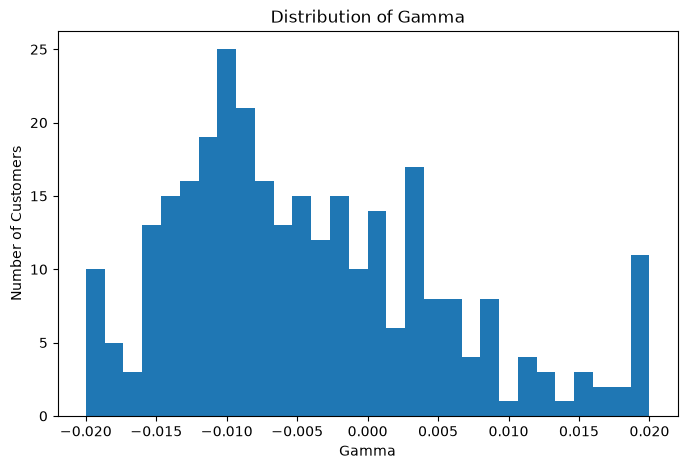

```python
import matplotlib.pyplot as plt

plt.figure(figsize=(8, 5))
plt.hist(parameters["gamma"], bins=30)
plt.xlabel("Gamma")
plt.ylabel("Number of Customers")
plt.title("Distribution of Gamma")
plt.show()
```

```python
# Prediction error for each observation
train_df["error"] = train_df["PPV_pred"] - train_df["PPV"]
train_df["abs_error"] = train_df["error"].abs()

# Customer-level table
error_by_customer = (
    train_df.groupby("Customer")
    .agg(
        gamma=("gamma", "first"),
        mean_error=("error", "mean"),
        MAE=("abs_error", "mean")
    ).reset_index())

# View table sorted by gamma
error_by_customer.sort_values("gamma")
```

|  | Customer | gamma | mean_error | MAE |
| --- | --- | --- | --- | --- |
| 263 | 264 | -0.02 | -0.000782 | 0.033660 |
| 189 | 190 | -0.02 | -0.002014 | 0.054365 |
| 56 | 57 | -0.02 | -0.003752 | 0.089804 |
| 265 | 266 | -0.02 | 0.000288 | 0.037688 |
| 251 | 252 | -0.02 | -0.000611 | 0.032194 |
| ... | ... | ... | ... | ... |
| 62 | 63 | 0.02 | 0.000195 | 0.028077 |
| 182 | 183 | 0.02 | 0.000044 | 0.050192 |
| 214 | 215 | 0.02 | 0.002963 | 0.034575 |
| 279 | 280 | 0.02 | 0.002250 | 0.040741 |
| 31 | 32 | 0.02 | 0.001590 | 0.043246 |

300 rows × 4 columns

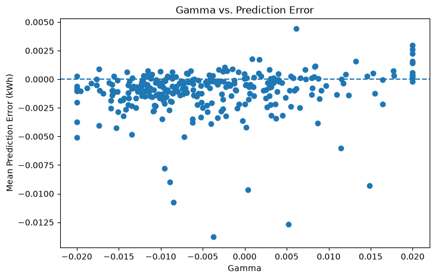

```python
plt.figure(figsize=(8, 5))
plt.scatter(error_by_customer["gamma"], error_by_customer["mean_error"])
plt.axhline(0, linestyle="--")
plt.xlabel("Gamma")
plt.ylabel("Mean Prediction Error (kWh)")
plt.title("Gamma vs. Prediction Error")
plt.show()
```

This plot suggests little relationship between $\gamma$ and mean prediction error. Most errors cluster slightly below zero, so the model generally underpredicts. The few large errors are scattered. This provides evidence that $\gamma$ is probably not the main source of systematic offset. Therefore the most likely problematic parameter seems to be $alpha$.

```python
alpha_check = (
    train_df.groupby("Customer")
    .agg(
        Generator_Capacity=("Generator Capacity", "first"),
        max_PPV=("PPV", "max"),
        alpha=("alpha", "first")).reset_index())

alpha_check["max_PPV_ratio"] = (
    alpha_check["max_PPV"] / alpha_check["Generator_Capacity"])

alpha_check.head()
```

|  | Customer | Generator_Capacity | max_PPV | alpha | max_PPV_ratio |
| --- | --- | --- | --- | --- | --- |
| 0 | 1 | 3.78 | 1.838 | 1.119017 | 0.486243 |
| 1 | 2 | 1.62 | 0.700 | 0.481045 | 0.432099 |
| 2 | 3 | 1.00 | 0.500 | 0.338140 | 0.500000 |
| 3 | 4 | 1.00 | 0.450 | 0.270474 | 0.450000 |
| 4 | 5 | 1.00 | 0.381 | 0.265757 | 0.381000 |

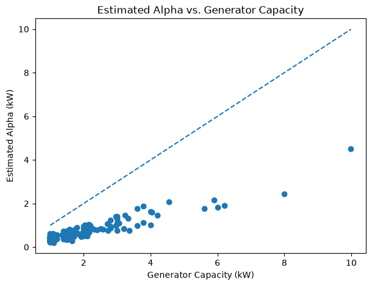

```python
plt.figure(figsize=(7, 5))

plt.scatter(
    alpha_check["Generator_Capacity"],
    alpha_check["alpha"])

x = np.linspace(
    alpha_check["Generator_Capacity"].min(),
    alpha_check["Generator_Capacity"].max(),
    100)

plt.plot(x, x, linestyle="--")

plt.xlabel("Generator Capacity (kW)")
plt.ylabel("Estimated Alpha (kW)")
plt.title("Estimated Alpha vs. Generator Capacity")
plt.show()
```

It is possible that the regression is using $\alpha$ to compensate for an overestimated effective irradiance term: $\frac{S(t)}{G_\text{STC} \max (0, \cos(\theta_\text{sun} - \beta))$. In particular, our use of $S(t) \cos (\theta_\text{sun} - \beta)$ may be physically inconsistent because `shortwave_radiation` is already a measure of radiation received on a particular surface, while the cosine factor is intended to account for the panel's orientation relative to the incorming solar rays. We want to investigate whether `shortwave radiation` and `sun position` are redundant. First we compare the pairwise relationships and calculate their correlations.

```python
# Correlations with true PV generation
print(
    train_df[["shortwave_radiation", "sun_position", "PPV"]]
    .corr()["PPV"])
```

```
shortwave_radiation    0.422491
sun_position          -0.307815
PPV                    1.000000
Name: PPV, dtype: float64
```

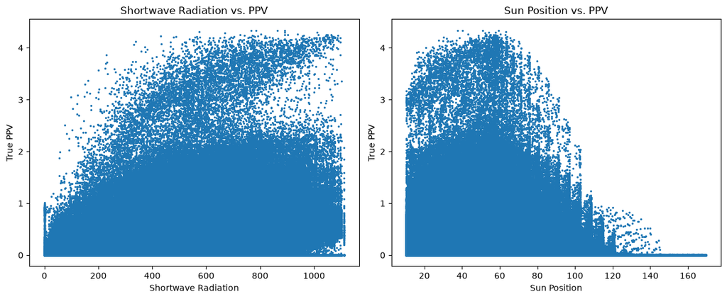

```python
fig, axes = plt.subplots(1, 2, figsize=(12, 5))

axes[0].scatter(
    train_df["shortwave_radiation"],
    train_df["PPV"],
    s=2)
axes[0].set_xlabel("Shortwave Radiation")
axes[0].set_ylabel("True PPV")
axes[0].set_title("Shortwave Radiation vs. PPV")

axes[1].scatter(
    train_df["sun_position"],
    train_df["PPV"],
    s=2)
axes[1].set_xlabel("Sun Position")
axes[1].set_ylabel("True PPV")
axes[1].set_title("Sun Position vs. PPV")

plt.tight_layout()
plt.show()
```

This result shows that there is an issue with how we are using sun position. `Shortwave radiation` have a positive correlation with PPV (0.42) and shows a fairly strong increasing relationship with PV output. `Sun position` has a negative correlation with PPV (-0.31), but the scatterplot shows a nonlinear relationship. PPV is generally highest at intermediate sun positions and approaches zero at large angles. This makes sense if `sun_position` is the solar zenith angle: panels receive little direct irradiant when the sun is near the horizon. However, the fact that shortwave radiation already contains the actual meassured radiation reaching the surface means it may already incorporate much of the effect of solar radiation.

# Final Notes

Before finding the physics-informed regression equation, we should first investigate the predictive power of each variable independently. In my opinion, our strongest predictive variable is sun position. This is because weather data can be difficult to aquire, but if we know the location of the system, sun position can be easily calculated without needing proprietary historical weather data. In addition to sun angle, we can some variable that can account for sunniness / cloudiness. Is there a better variable/variables from archive-api.open-meteo we could use? We should investigate the following Open-Meteo archive variables:

1. `shortwave_radiation` (GHI): Captures the effect of sun angle, clouds, aerosols, ect.. Open-Meteo defines it as global irradiation.
2. `cloud_cover` (%): Simple explicity cloudiness variable.
3. `direct_normal_irradiance` (DNI): Represents scattered radiation reaching the surface, including radiation affected by clouds. This could help explain PV production when direct sunlight is reduced.
4. `diffuse_radiation` (DHI): Represents scattered radiation reaching the surface, including radiation affected by clouds. This could help explain PV production when direct sunlight is reduced.
5. `sunlight_duration`: Measures the time during the preceding hour for which DNI exceeded the WMO sunshine threshold. This could be a useful alternative measure of cloudiness, although it is less continuous than cloud cover.